# Seurat Integration (Dataset 3)

Joey Hastings

2023-03-08

# Load Packages

```r
library(tictoc)
library(tidyverse)
library(cowplot)
library(ggExtra)
library(ggthemes)

library(splatter)
library(scater)
library(scran)
library(r.jive)
library(Seurat)
library(factoextra)
library(SLIDE)
library(RSpectra)

library(kBET) # kBET
library(cluster) # ASW
library(lisi) # LISI
library(mclust) # ARI

theme_set(theme_few())

method_name <- "Seurat"
dataset_name <- "dataset3"
```

# Simulation 1

## Generate Cell Counts

- Three cell types/groups (unbalanced)
- Two batches (balanced)
- Small dropout

```r
# Parameters that remain the same for all cell types
nGenes <- 5000
method = "single"
dropout.type = "experiment"
dropout.shape = -1
verbose = FALSE
```

```r
tic("Data Simulation")
sim1 <- splatSimulate(
  # Parameters to remain the same
  verbose = verbose,
  batchCells = c(500, 500),
  dropout.mid = 0.05,
  nGenes = nGenes,
  method = "groups",
  seed = 1,
  dropout.type = dropout.type,
  dropout.shape = dropout.shape,
  group.prob = c(0.6, 0.3, 0.1),
  # Parameters to tweak in each simulation
  batch.facLoc = 0.2,
  batch.facScale = 0.1,
  de.prob = c(0.01, 0.1, 0.5),
  de.downProb = c(0.01, 0.4, 0.9),
  de.facLoc = c(0.6, 1, 0.2),
  de.facScale = c(0.1, 0.4, 0.8),
  bcv.common = 1
)
toc()
```

```
## Data Simulation: 4.97 sec elapsed
```

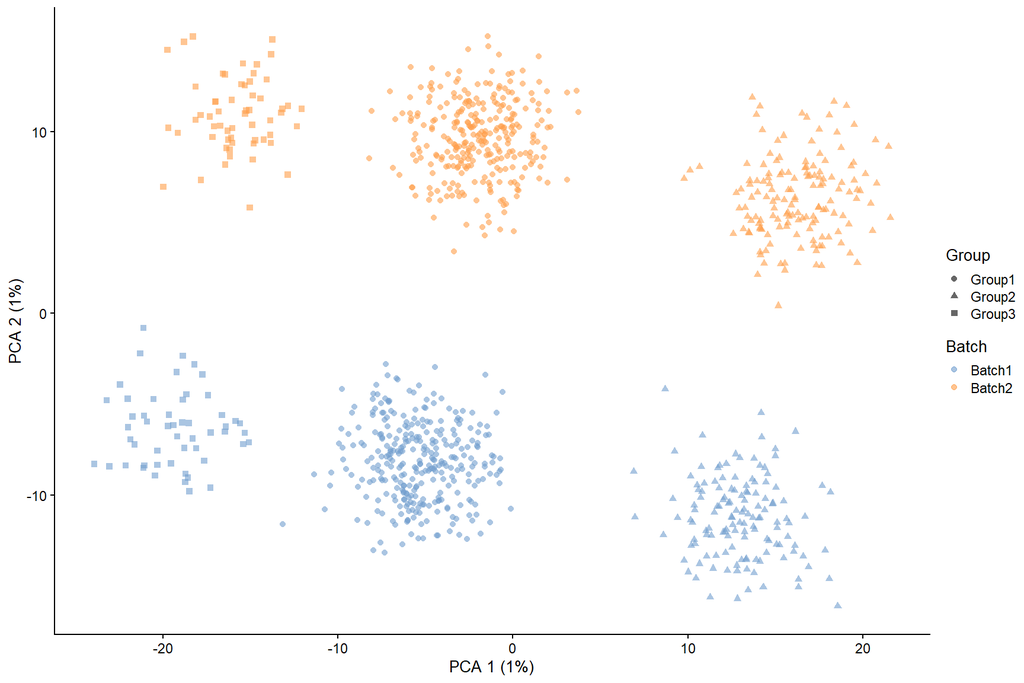

```r
sim1 <- logNormCounts(sim1)
sim1 <- addPerCellQC(sim1)
n.features <- colData(sim1)$detected
colData(sim1)$PctZero <- 100 * (1 - n.features/nrow(sim1))

# Dimension reduction visualization
set.seed(1)
sim1 <- runPCA(sim1, ncomponents = 30, ntop = 2000)
sim1 <- runTSNE(sim1)
sim1 <- runUMAP(sim1)
orig_p1 <- plotPCA(sim1, color_by = "Batch", shape_by = "Group")
orig_p2 <- plotTSNE(sim1, color_by = "Batch", shape_by = "Group")
orig_p3 <- plotUMAP(sim1, color_by = "Batch", shape_by = "Group")

orig_p1
```

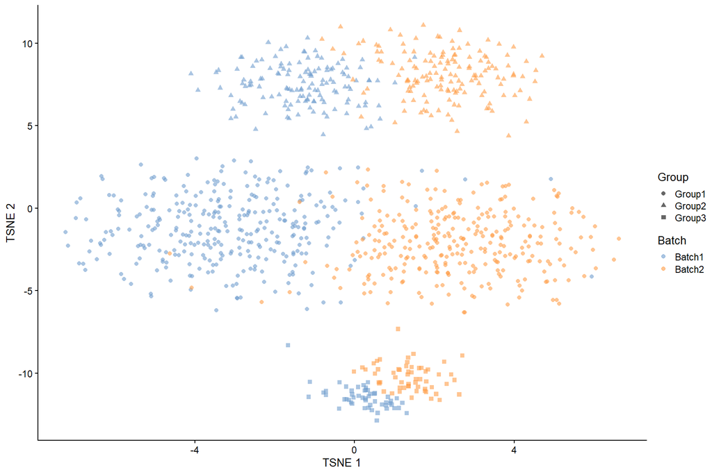

```r
orig_p2
```

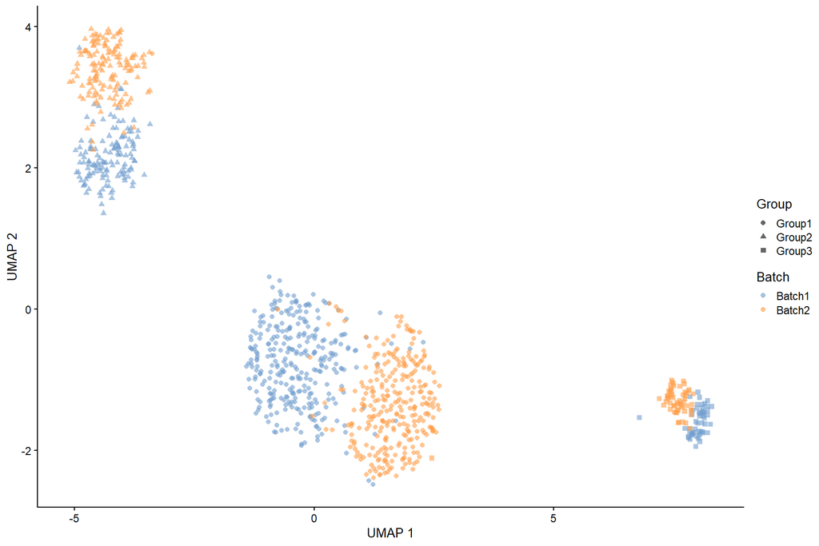

```r
orig_p3
```

## Separate Batches

```r
batches <- sim1$Batch
# Frequency of batches in simulation
table(batches)
```

```
## batches
## Batch1 Batch2
##    500    500
```

```r
groups <- sim1$Group
# Frequency of cell types in simulation
table(groups)
```

```
## groups
## Group1 Group2 Group3
##    606    284    110
```

```r
rawcounts <- counts(sim1)
dim(rawcounts)
```

```
## [1] 5000 1000
```

```r
b1 <- rawcounts[, batches == "Batch1"]
grp_b1 <- groups[batches == "Batch1"]
# Dimension of batch 1
dim(b1)
```

```
## [1] 5000  500
```

```r
# Frequency of cell types in batch 1
table(grp_b1)
```

```
## grp_b1
## Group1 Group2 Group3
##    312    136     52
```

```r
b2 <- rawcounts[, batches == "Batch2"]
grp_b2 <- groups[batches == "Batch2"]
# Dimension of batch 2
dim(b2)
```

```
## [1] 5000  500
```

```r
# Frequency of cell types in batch 2
table(grp_b2)
```

```
## grp_b2
## Group1 Group2 Group3
##    294    148     58
```

# Seurat

Perform cell batch integration as in their tutorial.

## Setup

- Create Seurat objects for each batch
  - Assign metadata to each object (batch number, cell type)
- Normalize the cell counts
- Identify most variable features (genes)
- Choose most variable features from both batches for use in integration

```r
b1_seurat <- CreateSeuratObject(counts = b1, project = "simulation")
b1_seurat <- AddMetaData(b1_seurat, "Batch1", col.name = "BatchNum")
b1_seurat <- AddMetaData(b1_seurat, grp_b1, col.name = "Group")

b2_seurat <- CreateSeuratObject(counts = b2, project = "simulation")
b2_seurat <- AddMetaData(b2_seurat, "Batch2", col.name = "BatchNum")
b2_seurat <- AddMetaData(b2_seurat, grp_b2, col.name = "Group")

seurat_list <- list(Batch1 = b1_seurat, Batch2 = b2_seurat)

# normalize and identify variable features for each dataset independently
seurat_list <- lapply(X = seurat_list, FUN = function(x) {
    x <- NormalizeData(x)
    x <- FindVariableFeatures(x, selection.method = "vst", nfeatures = 5000)
})

# select features that are repeatedly variable across datasets for integration
features <- SelectIntegrationFeatures(object.list = seurat_list, nfeatures = 5000)
```

## Integration

- Perform integration by finding a set of anchors from the two batches (via CCA)
- Use the anchor list to integrate the two batches

```r
anchors <- FindIntegrationAnchors(object.list = seurat_list, anchor.features = features)
```

```
## Scaling features for provided objects
```

```
## Finding all pairwise anchors
```

```
## Running CCA
```

```
## Merging objects
```

```
## Finding neighborhoods
```

```
## Finding anchors
```

```
##  Found 1949 anchors
```

```
## Filtering anchors
```

```
##  Retained 1136 anchors
```

```r
combined <- IntegrateData(anchorset = anchors)
```

```
## Merging dataset 2 into 1
```

```
## Extracting anchors for merged samples
```

```
## Finding integration vectors
```

```
## Finding integration vector weights
```

```
## Integrating data
```

```r
GetAssay(combined, "integrated")
```

```
## Assay data with 4949 features for 1000 cells
## Top 10 variable features:
##  Gene3835, Gene1022, Gene4384, Gene4030, Gene2891, Gene1852, Gene1621,
## Gene3611, Gene552, Gene3066
```

## Integrated Analysis

- Integrated/combined data is centered/scaled
- First 30 PCs are computed/stored
- PC1-PC30 are used to perform t-SNE and UMAP dimensionality reduction
- Calculates k-nearest neighbors (`k = 20` by default) from PC1-PC30
- Identify clusters by using Shared Nearest Neighbors (SNN):
  - “First calculate k-nearest neighbors and construct the SNN graph”
  - “Then optimize the modularity function to determine clusters”

```r
# specify that we will perform downstream analysis on the corrected data note that the
# original unmodified data still resides in the 'RNA' assay
DefaultAssay(combined) <- "integrated"

# Run the standard workflow for visualization and clustering
set.seed(1)
combined <- ScaleData(combined, verbose = FALSE)
combined <- RunPCA(combined, npcs = 30, verbose = FALSE)
combined <- RunTSNE(combined, reduction = "pca", dims = 1:30)
combined <- RunUMAP(combined, reduction = "pca", dims = 1:30)
combined <- FindNeighbors(combined, reduction = "pca", dims = 1:30)
combined <- FindClusters(combined, resolution = 0.5)
```

```
## Modularity Optimizer version 1.3.0 by Ludo Waltman and Nees Jan van Eck
##
## Number of nodes: 1000
## Number of edges: 102464
##
## Running Louvain algorithm...
## Maximum modularity in 10 random starts: 0.7553
## Number of communities: 3
## Elapsed time: 0 seconds
```

Visualize integrated batches and clusters using UMAP:

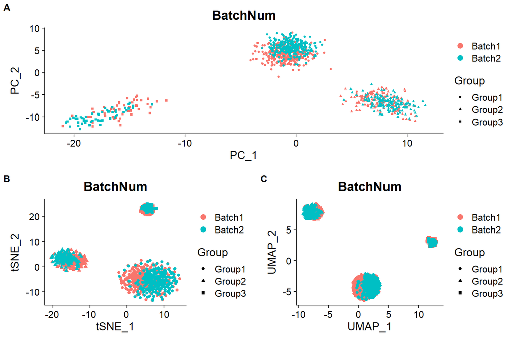

```r
# Visualization
dr1 <- DimPlot(combined, reduction = "pca", group.by = "BatchNum", shape.by = "Group")
dr2 <- DimPlot(combined, reduction = "tsne", group.by = "BatchNum", shape.by = "Group", pt.size = 1.5)
dr3 <- DimPlot(combined, reduction = "umap", group.by = "BatchNum", shape.by = "Group", pt.size = 1.5)

plots <- align_plots(dr1, dr2, align = 'v', axis = 'l')
# then build the bottom row
bottom_row <- plot_grid(plots[[2]], dr3, labels = c('B', 'C'), label_size = 12)

# then combine with the top row for final plot
dr_all <- plot_grid(plots[[1]], bottom_row, labels = c('A', ''), label_size = 12, ncol = 1)
dr_all
```

```r
# Frequency of true cell types/groups vs. identified clusters
table(combined@meta.data[, c("Group", "seurat_clusters")])
```

```
##         seurat_clusters
## Group      0   1   2
##   Group1 606   0   0
##   Group2   0 284   0
##   Group3   0   0 110
```

```r
seurat_final <- t(as.matrix(GetAssay(combined, "integrated")@data))
```

# Calculate kBET

- Sub-sample data at varying percentages
  - 5%, 10%, 15%, 20%, 25%
  - Stratified sampling so that each batch has the same number of cells selected
    - E.g., assume 2 batches, sampling 10% of 1000 cells = 100 cells: sample 50 cells from each batch
- Calculate kBET rejection rates at each percentage
  - **Lower** RR indicate well-mixed batches
  - **Higher** RR indicate poorly-mixed batches

```r
# data: a matrix (rows: samples, columns: features (genes))
data <- combined@reductions$pca@cell.embeddings

# batch: vector or factor with batch label of each cell
batch <- combined$BatchNum

sample_size <- seq(0.05, 0.25, by = 0.05)
rejection_rate <- list()

set.seed(1)
for (i in 1:length(sample_size)) {
  k <- floor(nrow(data) * sample_size[i])

  batch.estimate <- kBET(data, batch, k0 = k, plot = F, do.pca = F, verbose = T)

  if (class(batch.estimate) == "list") {
    rejection_rate[[i]] <- batch.estimate$summary %>%
      rownames_to_column(var = "statistic") %>%
      mutate(sample_size = sample_size[i]) %>%
      select(sample_size, statistic, kBET_rr = kBET.observed)
  }
}
```

```
## finding knns...done. Time:
##    user  system elapsed
##    0.08    0.00    0.08
## Number of kBET tests is set to 100.
## There are 62 cells (6.2%) that do not appear in any neighbourhood.
## The expected frequencies for each category have been adapted.
## Cell indexes are saved to result list.
## finding knns...done. Time:
##    user  system elapsed
##    0.09    0.00    0.10
## Number of kBET tests is set to 100.
## There are 29 cells (2.9%) that do not appear in any neighbourhood.
## The expected frequencies for each category have been adapted.
## Cell indexes are saved to result list.
## finding knns...done. Time:
##    user  system elapsed
##    0.11    0.00    0.10
## Number of kBET tests is set to 100.
## No outsiders found.finding knns...done. Time:
##    user  system elapsed
##    0.12    0.00    0.12
## Number of kBET tests is set to 100.
## No outsiders found.finding knns...done. Time:
##    user  system elapsed
##    0.14    0.00    0.14
## Number of kBET tests is set to 100.
## No outsiders found.
```

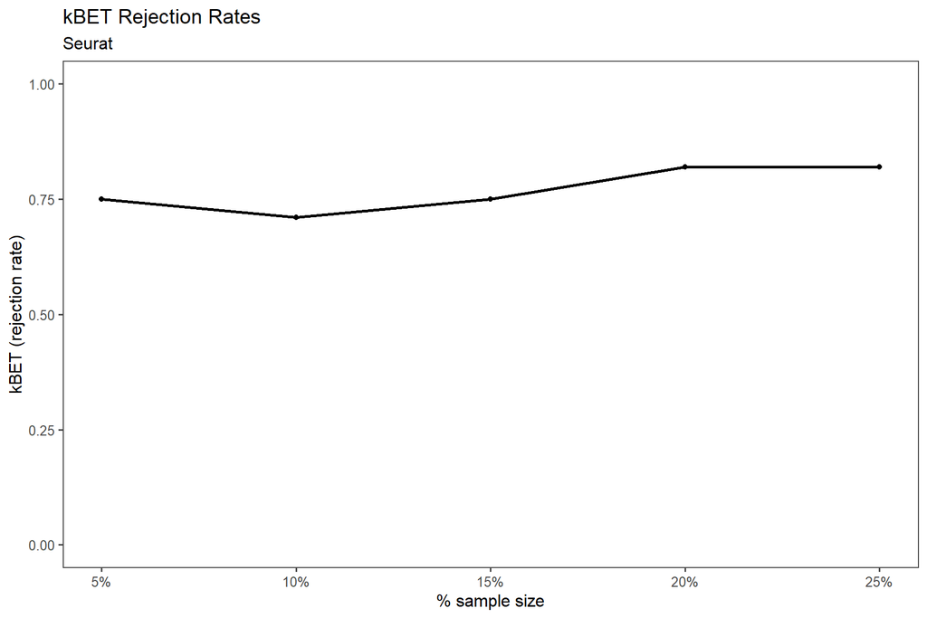

```r
all_rr <- bind_rows(rejection_rate) %>%
  mutate(method = method_name) %>%
  pivot_wider(id_cols = c(method, sample_size), names_from = statistic, values_from = kBET_rr) %>%
  select(method, sample_size, median_rr = `50%`)

all_rr %>% write_csv(file = paste0("output/", method_name, "_", dataset_name, "_kBET.csv"))

all_rr %>%
  ggplot(aes(x = sample_size, y = median_rr)) +
  geom_line(linewidth = 1) +
  geom_point() +
  scale_x_continuous(labels = scales::percent) +
  expand_limits(y = c(0, 1)) +
  labs(
    x = "% sample size",
    y = "kBET (rejection rate)",
    color = "Cell Group",
    title = "kBET Rejection Rates",
    subtitle = method_name
  )
```

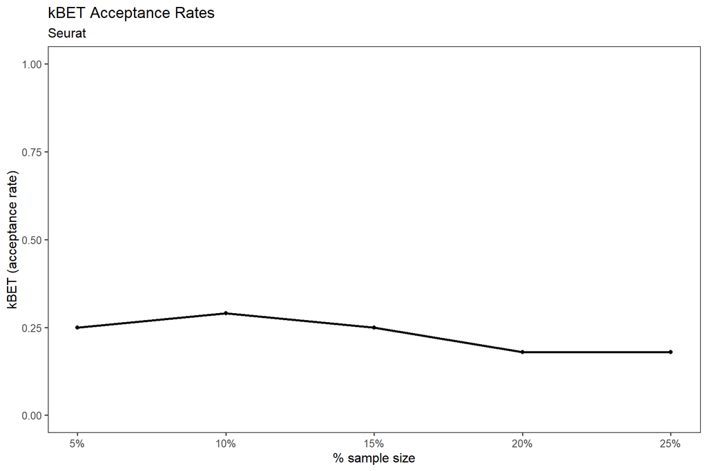

```r
all_rr %>%
  ggplot(aes(x = sample_size, y = I(1 - median_rr))) +
  geom_line(linewidth = 1) +
  geom_point() +
  scale_x_continuous(labels = scales::percent) +
  expand_limits(y = c(0, 1)) +
  labs(
    x = "% sample size",
    y = "kBET (acceptance rate)",
    color = "Cell Group",
    title = "kBET Acceptance Rates",
    subtitle = method_name
  )
```

# Calculate Average Silhouette Width

Original batch label and cell types/groups will be considered the clusters to compute $ASW_{batch}$ and $ASW_{group}$

- Compute average silhouette width (ASW) for the first 30 PCs of 80% sub-sample of joint data
  - ASW ranges between -1 and 1
  - Values **close to 1** indicate the cell is well-matched to its cluster (i.e., batch label)
  - Values **close to -1** indicate the cell is **not** well-matched to its cluster (i.e., batch label)
    - We hope to see lower values for $ASW_{batch}$ since it is indicative of well-mixed batches
    - We hope to see higher values for $ASW_{group}$ since it is indicative that distinct cell groups were preserved after batch-mixing
- Repeat `20` times
- Calculate the median ASW from the `20` runs to ensure stability of the measurement

```r
asw_repeat <- 20
npcs <- 30

asw_batch <- list()
asw_group <- list()
subset_prop <- 0.8 # subsample to 80% of the data
subset_size_total <- floor(length(batch) * subset_prop)

set.seed(1)
for (i in 1:asw_repeat) {
  subset_index <-
    data.frame(index = 1:length(batch) , batch = batch) %>%
    slice_sample(n = subset_size_total, replace = F)

  subset_id <- subset_index %>%
    pull(index)

  data_pc <- svds(seurat_final[subset_id, ], k = npcs)$u

  dissimilarity_matrix <- daisy(data_pc)

  asw_batch_i <- silhouette(as.integer(factor(batches[subset_id])), dissimilarity_matrix)
  asw_batch[[i]] <- as.data.frame(rbind(summary(asw_batch_i)[["si.summary"]]))

  asw_group_i <- silhouette(as.integer(factor(groups[subset_id])), dissimilarity_matrix)
  asw_group[[i]] <- as.data.frame(rbind(summary(asw_group_i)[["si.summary"]]))
}

all_asw_batch <- bind_rows(asw_batch) %>%
  mutate(Cluster = "Batch")

# ASW_batch summary
summary(all_asw_batch$Mean)
```

```
##     Min.  1st Qu.   Median     Mean  3rd Qu.     Max.
## 0.008563 0.010149 0.011079 0.011035 0.011998 0.012718
```

```r
all_asw_group <- bind_rows(asw_group) %>%
  mutate(Cluster = "Group")

#ASW_group summary
summary(all_asw_group$Mean)
```

```
##    Min. 1st Qu.  Median    Mean 3rd Qu.    Max.
## 0.04612 0.04740 0.04802 0.04803 0.04891 0.04947
```

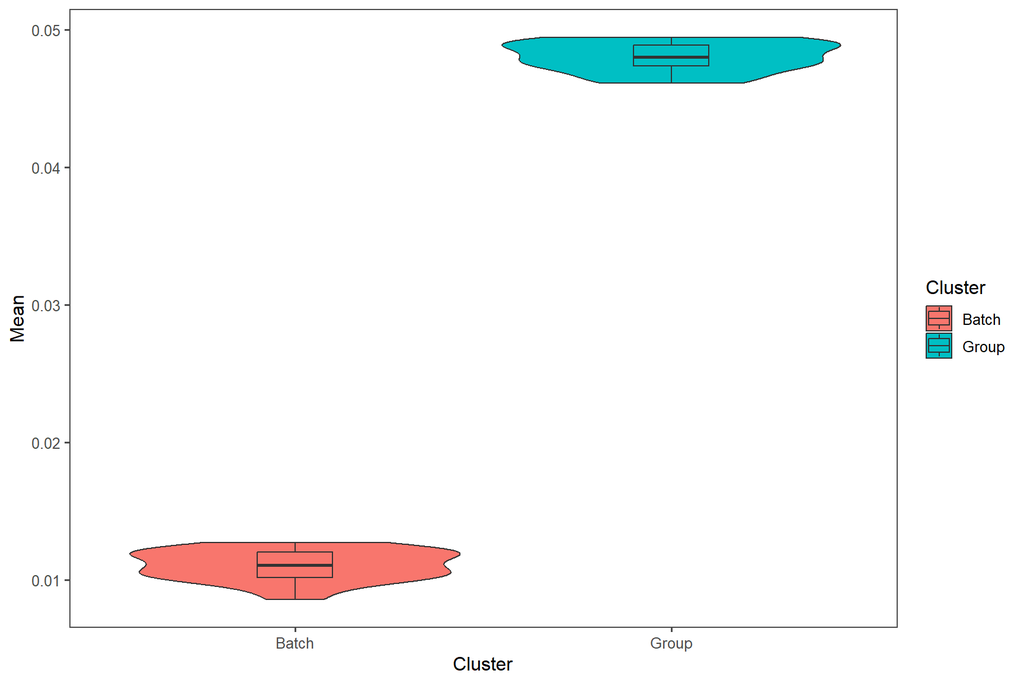

```r
all_asw <- bind_rows(all_asw_batch, all_asw_group)

asw_plot <- ggplot(data = all_asw, aes(x = Cluster, y = Mean, fill = Cluster)) +
  geom_violin() +
  geom_boxplot(width = 0.2)

asw_plot
```

```r
all_asw %>%
  group_by(Cluster) %>%
  mutate(Method = method_name) %>%
  write_csv(file = paste0("output/", method_name, "_", dataset_name, "_ASW.csv"))
```

# Calculate LISI Scores

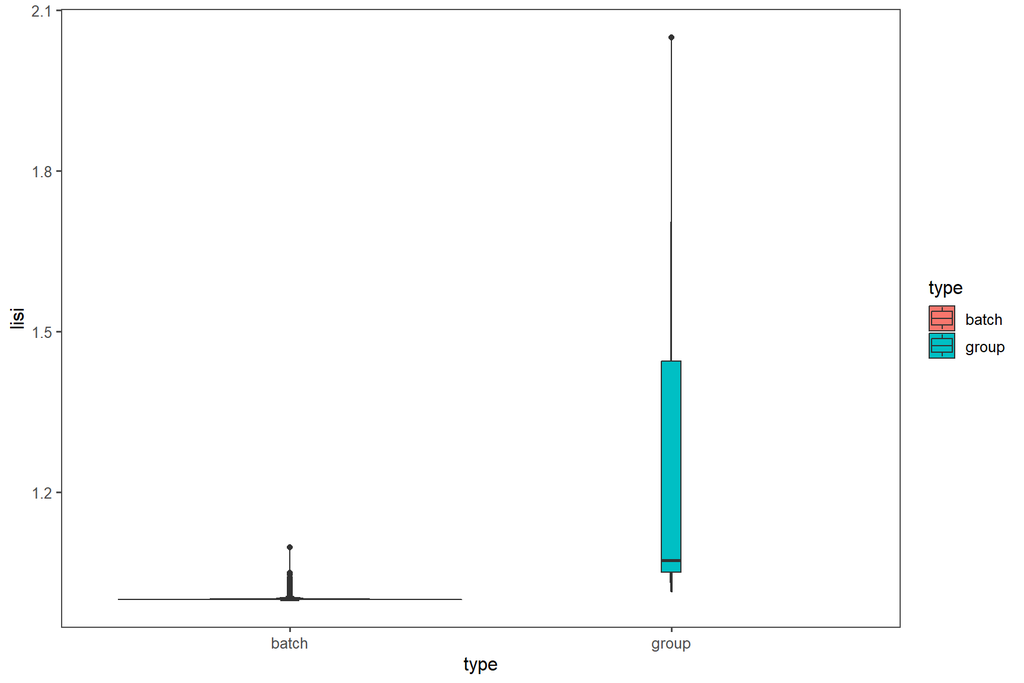

```r
# Performed for all cells

lisi <- compute_lisi(seurat_final, data.frame(batch = batches, group = groups), c("batch", "group"), perplexity = 40) %>%
  pivot_longer(cols = c("batch", "group"), names_to = "type", values_to = "lisi")

# Looking for values close to the number of batches (2)
# Looking for values close to 1

ggplot(data = lisi, aes(x = type, y = lisi, fill = type)) +
  geom_violin() +
  geom_boxplot(width = 0.05)
```